# Lab 5 - Subgroups

Douglas Luke

July 14, 2021

## Introduction

This lab corresponds to Chapter 8 - Subgroups.

This chapter and lab primarily uses the `igraph` package, which has a greater variety of useful subgroup detection functions.

```r
library(igraph)
library(UserNetR)
library(intergraph)
```

## Social Cohesion

### Cliques

One way to define subgroups in a network is to look for regions of a network that are defined by frequent or strong ties internal to the group. In social networks we think of these regions or subgroups as *socially cohesive.*

Cliques are the simplest and among the oldest of the formally defined subgroups based on social cohesion. A clique is a maximally complete subgroup, that is, a subgroup with all possible ties.

The following code prints a simple network with two cliques. It also demonstrates a nice feature of `igraph` where you can quickly create a small network using a simple graph formula.

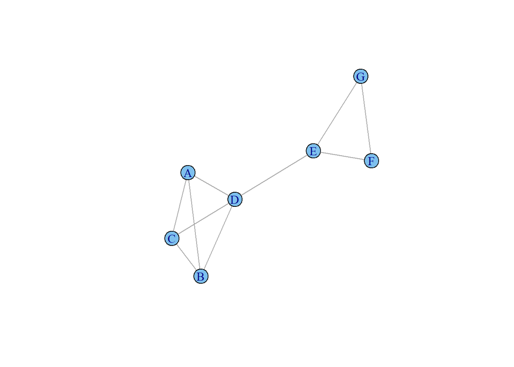

```r
clqexmp <- graph.formula(A:B:C:D--A:B:C:D,D-E,E-F-G-E)
plot(clqexmp,vertex.color="SkyBlue2")
```

Some basic commands for getting information about cliques in an `igraph` network object.

```r
clique.number(clqexmp)
```

```
## [1] 4
```

```r
cliques(clqexmp, min=3)
```

```
## [[1]]
## + 3/7 vertices, named, from 96b895a:
## [1] B C D
##
## [[2]]
## + 3/7 vertices, named, from 96b895a:
## [1] E F G
##
## [[3]]
## + 3/7 vertices, named, from 96b895a:
## [1] A B C
##
## [[4]]
## + 4/7 vertices, named, from 96b895a:
## [1] A B C D
##
## [[5]]
## + 3/7 vertices, named, from 96b895a:
## [1] A B D
##
## [[6]]
## + 3/7 vertices, named, from 96b895a:
## [1] A C D
```

```r
maximal.cliques(clqexmp,min=3)
```

```
## [[1]]
## + 3/7 vertices, named, from 96b895a:
## [1] E F G
##
## [[2]]
## + 4/7 vertices, named, from 96b895a:
## [1] A B D C
```

```r
largest.cliques(clqexmp)
```

```
## [[1]]
## + 4/7 vertices, named, from 96b895a:
## [1] D A B C
```

E: Try creating a slightly larger or more complicated network and use the above commands to detect and list the cliques in the network.

I include the following code more as a preview of material we will cover when we cover network modeling. Here, we are creating random networks and looking for cliques in them.

```r
g25 <- erdos.renyi.game(25, 75, type="gnm")
g50 <- erdos.renyi.game(50, 150, type="gnm")
g100 <- erdos.renyi.game(100, 300, type="gnm")
g500 <- erdos.renyi.game(500, 1500, type="gnm")
nodes <- c(25,50,100,500)
lrgclq <- c(clique.number(g25),clique.number(g50),
            clique.number(g100),clique.number(g500))
numclq <- c(length(cliques(g25,min=3)),
            length(cliques(g50,min=3)),
            length(cliques(g100,min=3)),
            length(cliques(g500,min=3)))
clqinfo <- data.frame(Nodes=nodes,Largest=lrgclq,
                      Number=numclq)
clqinfo
```

```
##   Nodes Largest Number
## 1    25       4     46
## 2    50       3     36
## 3   100       3     31
## 4   500       3     33
```

Q: Can you understand what is being done in the following code, and what information is collected in the dataframe? Hint: look at the help file for `erdos.renyi.game()`.

```r
g1 <- erdos.renyi.game(200, .01, type="gnp")
g2 <- erdos.renyi.game(200, .05, type="gnp")
g3 <- erdos.renyi.game(200, .10, type="gnp")
g4 <- erdos.renyi.game(200, .15, type="gnp")
prob <- c("1%","5%","10%","15%")
lrgclq <- c(clique.number(g1),clique.number(g2),
            clique.number(g3),clique.number(g4))
dens <- c(graph.density(g1),graph.density(g2),
          graph.density(g3),graph.density(g4))
numclq <- c(length(cliques(g1,min=3)),
            length(cliques(g2,min=3)),
            length(cliques(g3,min=3)),
            length(cliques(g4,min=3)))
clqinfo <- data.frame(Probability=prob,Density=dens,
                      Largest=lrgclq,
                      Number=numclq)
clqinfo
```

```
##   Probability     Density Largest Number
## 1          1% 0.009849246       3      1
## 2          5% 0.050653266       4    167
## 3         10% 0.100904523       4   1388
## 4         15% 0.154422111       5   5989
```

### k-cores

A more realistic and useful type of subgroup based on social cohesion is a k-core. A k-core is a maximal subgraph where every member of the subgraph has degree *k* or greater.

The following code loads the DHHS network, and transforms it into an `igraph` network object. Also, we create a new network that only retains edges that have ‘collab’ greater than 2 (only looking at formal collaborations). Note the cleaner syntax for accessing edge attributes (same is true for node attributes).

```r
data(DHHS)
library(intergraph)
iDHHS <- asIgraph(DHHS)
graph.density(iDHHS)
```

```
## [1] 0.312369
```

```r
iDHHS <- subgraph.edges(iDHHS,E(iDHHS)[collab > 2])
graph.density(iDHHS)
```

```
## [1] 0.1533688
```

Use `graph.coreness()` function to identify all the k-cores in a network.

```r
coreness <- graph.coreness(iDHHS)
table(coreness)
```

```
## coreness
##  1  2  3  4  5  6
##  7  6  2  5  2 26
```

```r
maxCoreness <- max(coreness)
maxCoreness
```

```
## [1] 6
```

Note how we use the special `name` and `color` node attributes. If they have information in them, `igraph` will use it for labeling and coloring nodes.

Also, we have to copy over the name, because `vertex.names` is a node attribute for `statnet`.

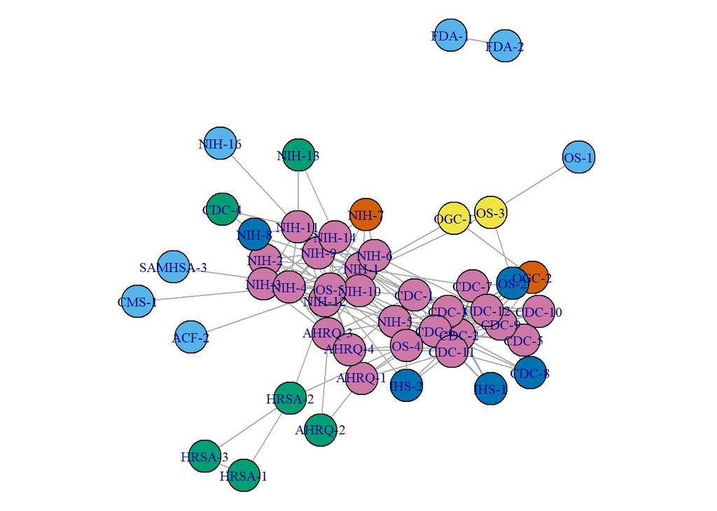

```r
Vname <- get.vertex.attribute(iDHHS,name='vertex.names',
                              index=V(iDHHS))
V(iDHHS)$name <- Vname
V(iDHHS)$color <- coreness + 1
op <- par(mar = rep(0, 4))
plot(iDHHS,vertex.label.cex=0.8)
```

```r
par(op)
```

When examining cores, it can be helpful to use the core value as a node attribute.

Also, see how we use `rainbow()` to set colors.

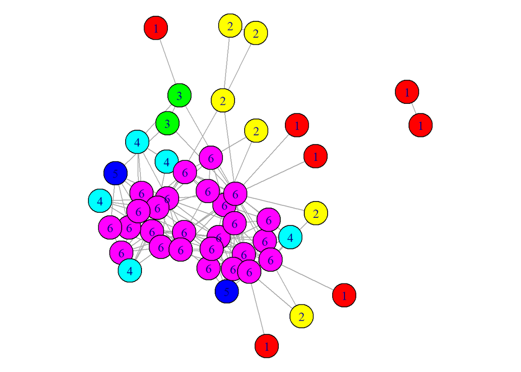

```r
colors <- rainbow(maxCoreness)
op <- par(mar = rep(0, 4))
plot(iDHHS,vertex.label=coreness,
     vertex.color=colors[coreness])
```

```r
par(op)
```

E: Rerun the above code, but after selecting ties that correspond to both informal and formal collaboration.

E: Try some of the other color options, see ?rainbow.

It can be very illuminating to ‘peel away’ the cores, to examine the highest-level cores. This works because of the nested structure of k-cores (all 3-cores are 2-cores as well, etc.).

Notice that we are filtering the network here, as we covered in the data management chapter.

```r
V(iDHHS)$name <- coreness
V(iDHHS)$color <- colors[coreness]
iDHHS1_6 <- iDHHS
iDHHS2_6 <- induced.subgraph(iDHHS,
                             vids=which(coreness > 1))
iDHHS3_6 <- induced.subgraph(iDHHS,
                             vids=which(coreness > 2))
iDHHS4_6 <- induced.subgraph(iDHHS,
                             vids=which(coreness > 3))
iDHHS5_6 <- induced.subgraph(iDHHS,
                             vids=which(coreness > 4))
iDHHS6_6 <- induced.subgraph(iDHHS,
                             vids=which(coreness > 5))
```

The following plotting code demonstrates a useful ‘power-tip.’ By saving the layout initially, we can use the same layout coordinates across multiple network panels.(A little more complicated than it might first seem.)

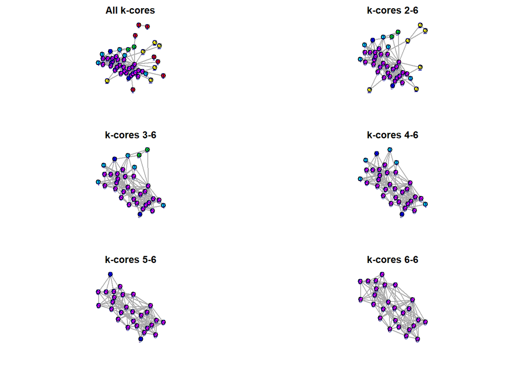

```r
lay <- layout.fruchterman.reingold(iDHHS)
op <- par(mfrow=c(3,2),mar = c(3,0,2,0))
plot(iDHHS1_6,layout=lay,main="All k-cores")
plot(iDHHS2_6,layout=lay[which(coreness > 1),],
     main="k-cores 2-6")
plot(iDHHS3_6,layout=lay[which(coreness > 2),],
     main="k-cores 3-6")
plot(iDHHS4_6,layout=lay[which(coreness > 3),],
     main="k-cores 4-6")
plot(iDHHS5_6,layout=lay[which(coreness > 4),],
     main="k-cores 5-6")
plot(iDHHS6_6,layout=lay[which(coreness > 5),],
     main="k-cores 6-6")
```

```r
par(op)
```

Q: Will the highest-level cores in a network always be a single connected component?

## Community Detection

Modern subgroup techniques tend to focus on subgroups defined by both internal (lots) and external (few) ties.

### Modularity

A statistic that is useful for detecting and describing subgroups. Modularity is the extent to which nodes exhibit clustering where there is greater density within the clusters and less density between them, with reference to some node classification.

```r
g1 <- graph.formula(A-B-C-A,D-E-F-D,G-H-I-G,A-D-G-A)
V(g1)$grp_good <- c(1,1,1,2,2,2,3,3,3)
V(g1)$grp_bad <- c(1,2,3,2,3,1,3,1,2)
```

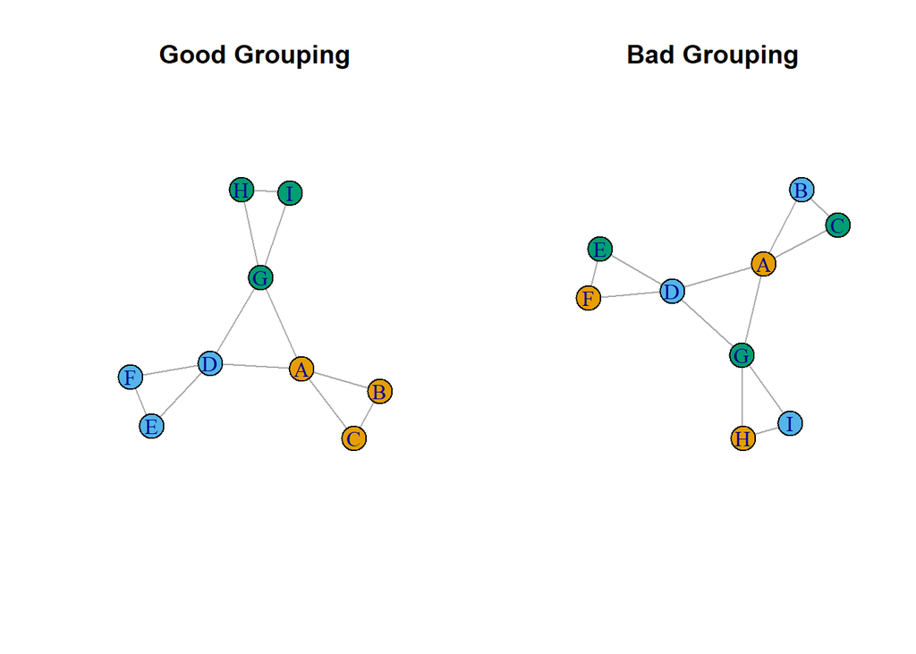

```r
op <- par(mfrow=c(1,2))
plot(g1,vertex.color=(V(g1)$grp_good),
     vertex.size=20,
     main="Good Grouping")
plot(g1,vertex.color=(V(g1)$grp_bad),
     vertex.size=20,
     main="Bad Grouping")
```

```r
par(op)
```

```r
modularity(g1,V(g1)$grp_good)
```

```
## [1] 0.4166667
```

```r
modularity(g1,V(g1)$grp_bad)
```

```
## [1] -0.3333333
```

Digression that demonstrates how to write a simple function that drives an even simpler simulation.(Note that I have replaced the older, deprecated `erdos.renyi.game()` with the newer function name `sample_gnp()`.)

```r
ran_mod <- function(){
  dum <- sample_gnp(100,.1)
  V(dum)$class <- sample(c("A","B","C","D"),100,replace=TRUE)
  mod <- modularity(dum,factor(V(dum)$class))
  mod
}
```

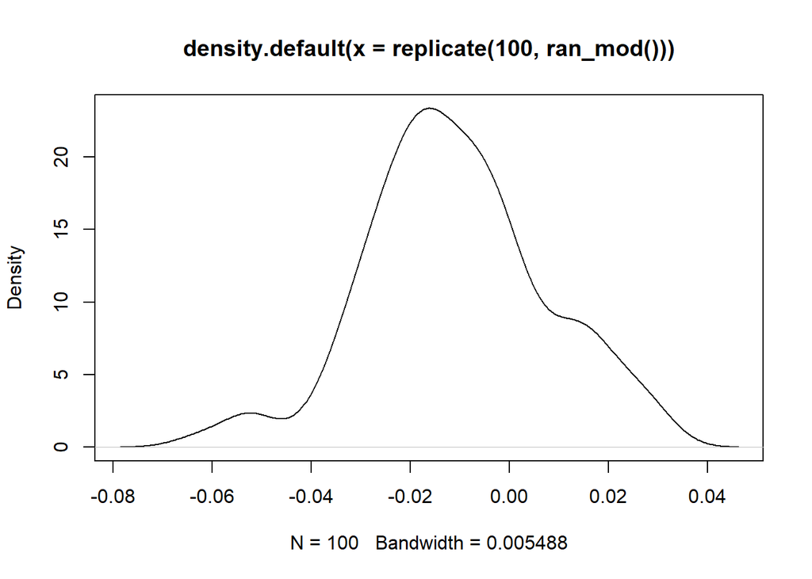

```r
plot(density(replicate(100,ran_mod())))
```

Here is how to calculate modularity for a network with an existing cliassification variable.

Have to transfrom the network again because of some earlier code.

Also, note how we had to add a 1 to the `agency` code. This is because of a bug in the `modularity()` function–it crashes if one of the values is 0 (or missing).

```r
iDHHS <- asIgraph(DHHS)
table(V(iDHHS)$agency)
```

```
##
##  0  1  2  3  4  5  6  7  8  9 10
##  2  4 12  2  2  3  2 16  3  5  3
```

```r
V(iDHHS)[1:10]$agency
```

```
##  [1] 0 0 1 1 1 1 2 2 2 2
```

```r
modularity(iDHHS,(V(iDHHS)$agency+1))
```

```
## [1] 0.1402264
```

Some other examples from the datasets.

```r
data(Moreno)
iMoreno <- asIgraph(Moreno)
table(V(iMoreno)$gender)
```

```
##
##  1  2
## 16 17
```

```r
modularity(iMoreno,V(iMoreno)$gender)
```

```
## [1] 0.4761342
```

```r
data(Facebook)
levels(factor(V(Facebook)$group))
```

```
## [1] "B" "C" "F" "G" "H" "M" "S" "W"
```

```r
grp_num <- as.numeric(factor(V(Facebook)$group))
modularity(Facebook,grp_num)
```

```
## [1] 0.6145798
```

E: Examine the plots of these networks, color coding the nodes by the classification variables. Does it make sense to you that the Moreno and Facebook networks have greater modularity than the DHHS network? Continue to explore some of the other networks, and try to guess ahead of time which classification variables are likely to show higher or lower modularity scores. For example, what would expect to see for the FIFA_Nether network?

### Community detection algorithms

A number of good community detection algorithms are supported in `igraph`. The basic approach is to run one of these functions on a network, storing the results in a membership object. This object can then be used in a number of ways, including plotting.

Notice here that the `modularity()` function can be run directly on a membership object.

```r
cw <- cluster_walktrap(iMoreno)
membership(cw)
```

```
##  [1] 1 1 1 1 1 1 1 1 3 3 3 5 5 5 5 1 3 2 2 2 4 4 4 2 2 2 2 2 2 2 2 6 6
```

```r
modularity(cw)
```

```
## [1] 0.6181475
```

Now, we can make a very pretty (and useful) figure!

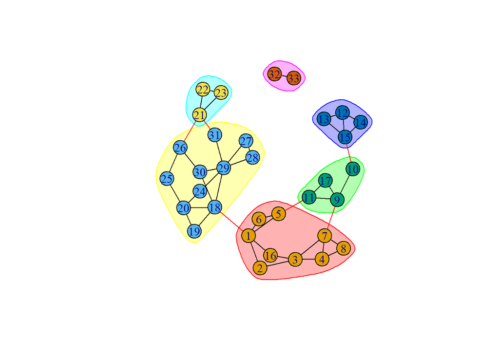

```r
plot(cw, iMoreno)
```

E: Pick a different community detection algorithm in igraph, and use it on the iMoreno igraph network. How does it compare to the ‘cluster_walktrap’ algorithm?

Comparing a cluster solution based on the ‘walktrap’ algorithm to the existing agency node characteristics.

```r
cw <- cluster_walktrap(iDHHS)
modularity(cw)
```

```
## [1] 0.1653754
```

```r
membership(cw)
```

```
##  [1] 4 5 1 1 1 1 1 1 1 1 1 1 1 1 1 1 1 1 1 1 1 1 1 1 1 1 1 3 3 3 3 3 3 3 3 3 3 3
## [39] 3 3 3 3 3 2 2 2 2 1 2 1 1 1 1 1
```

```r
table(V(iDHHS)$agency,membership(cw))
```

```
##
##       1  2  3  4  5
##   0   0  0  0  1  1
##   1   4  0  0  0  0
##   2  12  0  0  0  0
##   3   2  0  0  0  0
##   4   2  0  0  0  0
##   5   3  0  0  0  0
##   6   2  0  0  0  0
##   7   0  0 16  0  0
##   8   0  3  0  0  0
##   9   3  2  0  0  0
##   10  3  0  0  0  0
```

Comparing multiple community detection algorithms to each other.

```r
data(Bali)
iBali <- asIgraph(Bali)
cw <- cluster_walktrap(iBali)
modularity(cw)
```

```
## [1] 0.2830688
```

```r
membership(cw)
```

```
##  [1] 2 1 2 1 2 2 1 2 2 3 3 3 3 3 2 2 2
```

```r
ceb <- cluster_edge_betweenness(iBali)
modularity(ceb)
```

```
## [1] 0.2387251
```

```r
membership(ceb)
```

```
##  [1] 1 1 1 1 1 1 1 1 1 2 2 2 2 2 1 1 1
```

```r
cs <- cluster_spinglass(iBali)
modularity(cs)
```

```
## [1] 0.2954145
```

```r
membership(cs)
```

```
##  [1] 2 1 2 3 2 1 1 2 2 3 3 3 3 3 2 2 2
```

```r
cfg <- cluster_fast_greedy(iBali)
modularity(cfg)
```

```
## [1] 0.2629126
```

```r
membership(cfg)
```

```
##  [1] 2 2 1 2 1 2 2 1 1 3 3 3 3 3 1 1 1
```

```r
clp <- cluster_label_prop(iBali)
modularity(clp)
```

```
## [1] 0.2387251
```

```r
membership(clp)
```

```
##  [1] 1 1 1 1 1 1 1 1 1 2 2 2 2 2 1 1 1
```

```r
cle <- cluster_leading_eigen(iBali)
modularity(cle)
```

```
## [1] 0.2750063
```

```r
membership(cle)
```

```
##  [1] 1 1 1 2 1 1 2 1 1 2 2 2 2 2 1 1 1
```

```r
cl <- cluster_louvain(iBali)
modularity(cl)
```

```
## [1] 0.2966742
```

```r
membership(cl)
```

```
##  [1] 3 1 3 2 3 3 1 3 3 2 2 2 2 2 3 3 3
```

```r
co <- cluster_optimal(iBali)
modularity(co)
```

```
## [1] 0.2966742
```

```r
membership(co)
```

```
##  [1] 1 2 1 3 1 1 2 1 1 3 3 3 3 3 1 1 1
```

Using a more formal classification comparison statistic to examine the similarities among multiple detection approaches.

```r
table(V(iBali)$role,membership(cw))
```

```
##
##      1 2 3
##   BM 0 5 0
##   CT 1 2 0
##   OA 2 1 0
##   SB 0 1 1
##   TL 0 0 4
```

```r
compare(as.numeric(factor(V(iBali)$role)),cw,
        method="adjusted.rand")
```

```
## [1] 0.3504908
```

```r
compare(cw,ceb,method="adjusted.rand")
```

```
## [1] 0.6155779
```

```r
compare(cw,cs,method="adjusted.rand")
```

```
## [1] 0.7251545
```

```r
compare(cw,cfg,method="adjusted.rand")
```

```
## [1] 0.6691802
```

E: How else can you use the `compare()` function?

As usual, plotting can reveal a tremendous amount of important information.

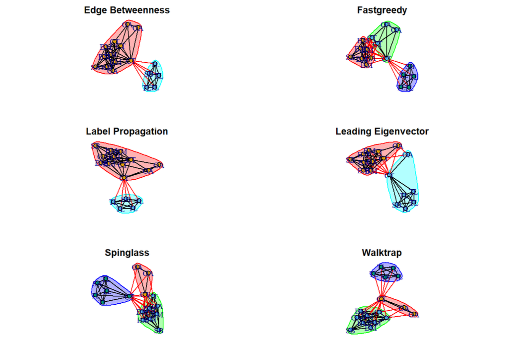

```r
op <- par(mfrow=c(3,2),mar=c(3,0,2,0))
plot(ceb, iBali,vertex.label=V(iBali)$role,
     main="Edge Betweenness")
plot(cfg, iBali,vertex.label=V(iBali)$role,
     main="Fastgreedy")
plot(clp, iBali,vertex.label=V(iBali)$role,
     main="Label Propagation")
plot(cle, iBali,vertex.label=V(iBali)$role,
     main="Leading Eigenvector")
plot(cs, iBali,vertex.label=V(iBali)$role,
     main="Spinglass")
plot(cw, iBali,vertex.label=V(iBali)$role,
     main="Walktrap")
```

```r
par(op)
```